# Cruising speed versus average speed

## Required packages

Packages that needs to be installed:

```r
from_cran <- c("dplyr", "magrittr", "parallel", "purrr", "tidyr", "RColorBrewer",
               "readr", "R.utils", "stringr")
to_install <- setdiff(from_cran, installed.packages()[, "Package"])
if (length(to_install)) install.packages(to_install)
```

The `FITfileR` package also needs to be installed from [Github](https://github.com/grimbough/FITfileR). Loading some of these packages:

```r
library(FITfileR)
library(dplyr)
library(purrr)
library(parallel)
library(magrittr)
```

## Downloading Strava activities

- Hover over your name in the upper right-hand corner of the Strava page. Choose `Settings`, then find the `My Account` tab from the menu listed on the Left.
- Select `Get Started` under `Download or Delete Your Account`
- Select `Request your archive` on the next page.

You will receive an email with a link to download your data (this may take a few hours). For this reason, it’s important that you have access to the email account attached to your Strava profile. More info [here](https://support.strava.com/hc/en-us/articles/216918437-Exporting-your-Data-and-Bulk-Export#h_01GG58HC4F1BGQ9PQZZVANN6WF).

I’ve put my Strava data here:

```r
data_folder <- "~/Library/CloudStorage/OneDrive-OxfordUniversityClinicalResearchUnit/data/Strava/"
```

and the downloaded data are in this subfolder:

```r
raw_strava <- "export_34225766/"
```

Retrieving the names of the files that correspond to cycling activities since 2022:

```r
# files <- "~/Desktop/export_34225766/activities.csv" |>
files <- paste0(data_folder, raw_strava, "activities.csv") |>
  readr::read_csv() |>
  tidyr::separate_wider_delim(`Activity Date`, ",",
                              names = c("day", "year", "time")) |>
  mutate(across("year", as.integer)) |>
  filter(`Activity Type` == "Ride", year > 2021) |>
  pull(Filename)
```

Keeping only the FIT files:

```r
files <- files[grep("fit", files)]
```

Let’s copy the cycling activities to another folder in which we will decompress them:

```r
riding_folder <- paste0(data_folder, "activities/")
dir.create(riding_folder)
dest <- paste0(riding_folder, files)
file.copy(paste0(data_folder, raw_strava, files), dest)
walk(dest, R.utils::gunzip)
```

## Some utilitary functions

Converts speed from m/s to km/h:

```r
ms2kmh <- function(x) 3.6 * x
```

Extracts the speeds values from the data structure:

```r
extract_speeds <- function(x) {
  idx <- grep("speed", names(x))
  if (length(idx)) return(as.vector(x[[idx]]))
  NULL
}
```

Makes sure that the output of `records()` is a list:

```r
make_list <- function(x) {
  if (is.data.frame(x)) return(list(x))
  x
}
```

Retrieves speeds from an activity:

```r
get_speed <- function(x) {
  x |>
    readFitFile() |>
    records() |>
    make_list() |>
    map(extract_speeds) %>%
    do.call(c, .) |>
    ms2kmh()
}
```

Computes the cruising speed as the mode of the distribution of speeds:

```r
cruising_speed <- function(x) {
  dens <- density(x)
  dens$x[which.max(dens$y)]
}
```

## Example on one activity

The blue curve is the distribution of speeds during the activity and the red and green vertical lines show the average and cruising speeds respectively:

```r
sp <- get_speed(paste0(data_folder, "activities/10517736664.fit"))
dens <- density(sp)
plot(dens, xlim = c(0, max(dens$x)), ylim = c(0, 1.03 * max(dens$y)),
     xaxs = "i", yaxs = "i",
     main = NA, xlab = "speed (km/h)", ylab = "density", col = 4, lwd = 3)
(asp <- mean(sp))
```

```
## [1] 35.83077
```

```r
(csp <- cruising_speed(sp))
```

```
## [1] 40.91778
```

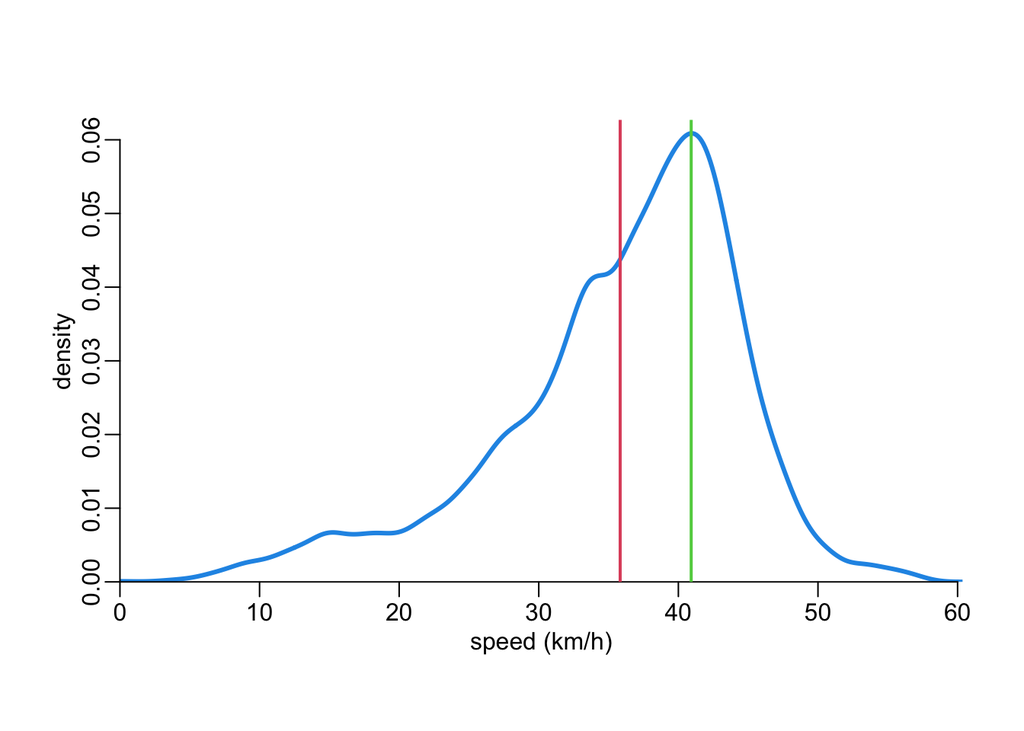

```r
abline(v = c(asp, csp), col = 2:3, lwd = 2)
```

It shows for example that the average speed is 35.8 km/h (red vertical line) whereas the cruising speed is actually 40.9 km/h (green vertical line).

## Processing all the cycling acitivities

Computes the average and cruising speeds from a vector of speeds:

```r
speeds <- function(x) {
  c(mean, cruising_speed) |>
    map_dfc(function(f) f(x)) |>
    setNames(c("average", "cruising"))
}
```

Reads a compressed FIT file from disk and compute the average and cruising speeds from it:

```r
read_file <- function(x) {
  x |>
    get_speed() |>
    speeds()
}
```

Processing all the files:

```r
speeds_lst <- files |>
  stringr::str_remove(".gz") %>%
  paste0(data_folder, .) |>
  mclapply(read_file, mc.cores = detectCores() - 1) |>
  bind_rows()
```

Modelling the cruising speed as a function of the average speed:

```r
mod <- lm(cruising ~ average, speeds_lst)
```

The model’s parameters estimates are the following:

```r
coef(mod)
```

```
## (Intercept)     average
##   6.1209262   0.9026573
```

Which means that, as a rule of thumb, you can obtain cruising speed by adding 6 km/h to 90% of the value of the average speed. But, more precisely, the following function converts the cruising speed into average speed from the above model:

```r
intercept <- coef(mod)[1]
slope <- coef(mod)[2]

cs2av <- function(x) {
  (x - intercept) / slope
}
```

The cruising speeds that define the groups:

```r
crsp <- c(40, 37, 41, 34, 38, 31, 35, 25, 30)
```

A function that nicely formats speed ranges:

```r
speed_range <- function(x) {
  c(paste0(x[1], "+ km/h"),
    map_chr(as.data.frame(matrix(x[-1], 2)),
            function(y) paste0(y[1], "-", y[2], " km/h")))
}
```

The comparison of cruising and average speeds for the groups:

```r
avsp <- cs2av(crsp)

groups <- c("A", "B+", "B", "C", "D")

data.frame(
  group          = groups,
  cruising_speed = speed_range(crsp),
  average_speed  = speed_range(round(avsp))
)
```

```
##    group cruising_speed average_speed
##        A       40+ km/h      38+ km/h
## V1    B+     37-41 km/h    34-39 km/h
## V2     B     34-38 km/h    31-35 km/h
## V3     C     31-35 km/h    28-32 km/h
## V4     D     25-30 km/h    21-26 km/h
```

Let’s see the data points and the model:

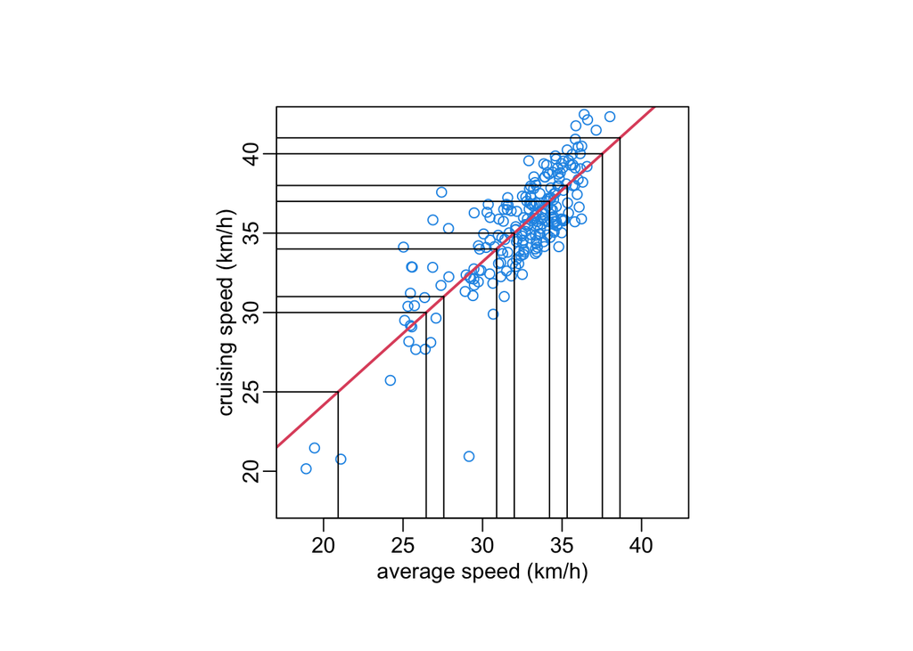

```r
opar <- par(pty = "s")
axlim <- c(18, 42)
nb <- length(crsp)

with(speeds_lst,
     plot(average, cruising, col = 4, xlim = axlim, ylim = axlim,
          xlab = "average speed (km/h)", ylab = "cruising speed (km/h)"))
abline(mod, col = 2, lwd = 2)

segments(rep(0, nb), crsp, avsp, crsp)
segments(avsp, rep(0, nb), avsp, crsp)
box(bty = "o")
```

```r
par(opar)
```

## Exploring another model

```r
new_limits <- c(20, 30.5, 34.5, 37.5, 40.5, 50)
```

```r
speeds_lst %<>% mutate(group = rev(groups)[as.numeric(cut(cruising, new_limits))])
```

```r
(tmp <- table(speeds_lst$group))
```

```
##
##  A  B B+  C  D
##  6 99 45 54 16
```

```r
round(100 * tmp / nrow(speeds_lst), 1)
```

```
##
##    A    B   B+    C    D
##  2.7 45.0 20.5 24.5  7.3
```

```r
n <- 1000
f <- 20
t <- 40

remove_ends <- function(x) {
  x[-c(1, length(x))]
}

groups_names <- sort(groups)

ordered_groups_names <- c("D", "C", "B", "B+", "A")

averagesp_limits <- speeds_lst |>
  group_by(group) |>
  group_map(~ pull(.x, average) |> density(n = n, from = f, to = t)) |>
  map_dfc(extract2, "y") |>
  setNames(groups_names) |>
  mutate(x = seq(f, t, l = n)) |>
  rowwise() |>
  mutate(mostlik = groups_names[which.max(c_across(A:D))]) |>
  group_by(mostlik) |>
  group_map(~ pull(.x, x) |> range()) |>
  setNames(groups_names) |>
  extract(ordered_groups_names) |>
  unlist() |>
  remove_ends() |>
  matrix(2) |>
  as.data.frame() |>
  map_dbl(mean)
```

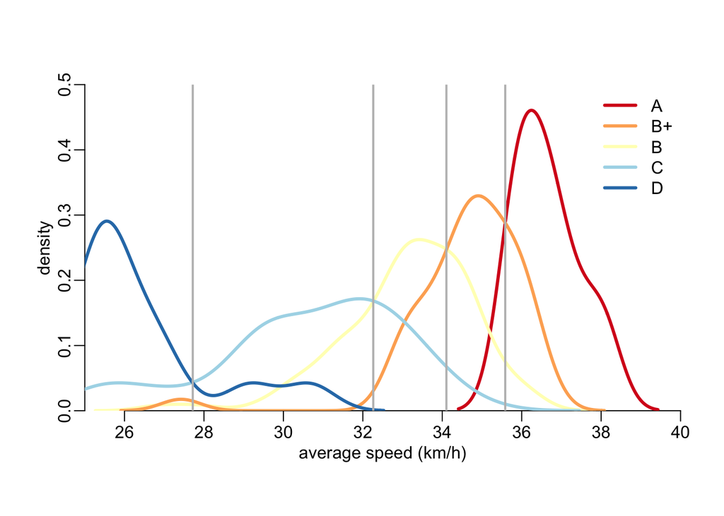

```r
lwd_val <- 3

add_density <- function(x, ...) {
  x |>
    pull(average) |>
    density() %>%
    lines(., ...)
}

plot(NA, xlim = c(25, 40), ylim = c(0, .5), xlab = "average speed (km/h)",
     ylab = "density", xaxs = "i", yaxs = "i")

rev_ordered_groups_names <- rev(ordered_groups_names)

groups_colors <- RColorBrewer::brewer.pal(5, "RdYlBu")

speeds_lst |>
  group_by(group) |>
  group_split() %>%
  walk2(groups_colors[order(rev_ordered_groups_names)],
        ~ add_density(.x, lwd = lwd_val, col = .y))

abline(v = averagesp_limits, lwd = 2, col = "grey")

legend("topright", legend = rev_ordered_groups_names, col = groups_colors, lwd = lwd_val, bty = "n")
```

```r
data.frame(
  group           = groups,
  cruising_speed  = speed_range(crsp),
  average_speed_1 = speed_range(round(avsp)),
  average_speed_2 = speed_range(round(c(rep(rev(averagesp_limits), each = 2), 20)[c(1, 3, 2, 5, 4, 7, 6, 9, 8)]))
)
```

```
##    group cruising_speed average_speed_1 average_speed_2
##        A       40+ km/h        38+ km/h        36+ km/h
## V1    B+     37-41 km/h      34-39 km/h      34-36 km/h
## V2     B     34-38 km/h      31-35 km/h      32-34 km/h
## V3     C     31-35 km/h      28-32 km/h      28-32 km/h
## V4     D     25-30 km/h      21-26 km/h      20-28 km/h
```